# 1. Apply Linear Regression on give dataset and predict the output target variable ("quality"). Please plot all the necessary plots like input data, loss, predicted vs actual values in the plot [15 pts]

Input data:

```python
import pandas as pd
import numpy as np
import matplotlib.pyplot as plt

df1 = pd.read_csv("Problem1_winequality.csv")
df1
```

|  | fixed acidity | volatile acidity | citric acid | residual sugar | chlorides | free sulfur dioxide | total sulfur dioxide | density | pH | sulphates | alcohol | quality |
| --- | --- | --- | --- | --- | --- | --- | --- | --- | --- | --- | --- | --- |
| 0 | 7.4 | 0.700 | 0.00 | 1.9 | 0.076 | 11.0 | 34.0 | 0.99780 | 3.51 | 0.56 | 9.4 | 5 |
| 1 | 7.8 | 0.880 | 0.00 | 2.6 | 0.098 | 25.0 | 67.0 | 0.99680 | 3.20 | 0.68 | 9.8 | 5 |
| 2 | 7.8 | 0.760 | 0.04 | 2.3 | 0.092 | 15.0 | 54.0 | 0.99700 | 3.26 | 0.65 | 9.8 | 5 |
| 3 | 11.2 | 0.280 | 0.56 | 1.9 | 0.075 | 17.0 | 60.0 | 0.99800 | 3.16 | 0.58 | 9.8 | 6 |
| 4 | 7.4 | 0.700 | 0.00 | 1.9 | 0.076 | 11.0 | 34.0 | 0.99780 | 3.51 | 0.56 | 9.4 | 5 |
| 5 | 7.4 | 0.660 | 0.00 | 1.8 | 0.075 | 13.0 | 40.0 | 0.99780 | 3.51 | 0.56 | 9.4 | 5 |
| 6 | 7.9 | 0.600 | 0.06 | 1.6 | 0.069 | 15.0 | 59.0 | 0.99640 | 3.30 | 0.46 | 9.4 | 5 |
| 7 | 7.3 | 0.650 | 0.00 | 1.2 | 0.065 | 15.0 | 21.0 | 0.99460 | 3.39 | 0.47 | 10.0 | 7 |
| 8 | 7.8 | 0.580 | 0.02 | 2.0 | 0.073 | 9.0 | 18.0 | 0.99680 | 3.36 | 0.57 | 9.5 | 7 |
| 9 | 7.5 | 0.500 | 0.36 | 6.1 | 0.071 | 17.0 | 102.0 | 0.99780 | 3.35 | 0.80 | 10.5 | 5 |
| 10 | 6.7 | 0.580 | 0.08 | 1.8 | 0.097 | 15.0 | 65.0 | 0.99590 | 3.28 | 0.54 | 9.2 | 5 |
| 11 | 7.5 | 0.500 | 0.36 | 6.1 | 0.071 | 17.0 | 102.0 | 0.99780 | 3.35 | 0.80 | 10.5 | 5 |
| 12 | 5.6 | 0.615 | 0.00 | 1.6 | 0.089 | 16.0 | 59.0 | 0.99430 | 3.58 | 0.52 | 9.9 | 5 |
| 13 | 7.8 | 0.610 | 0.29 | 1.6 | 0.114 | 9.0 | 29.0 | 0.99740 | 3.26 | 1.56 | 9.1 | 5 |
| 14 | 8.9 | 0.620 | 0.18 | 3.8 | 0.176 | 52.0 | 145.0 | 0.99860 | 3.16 | 0.88 | 9.2 | 5 |
| 15 | 8.9 | 0.620 | 0.19 | 3.9 | 0.170 | 51.0 | 148.0 | 0.99860 | 3.17 | 0.93 | 9.2 | 5 |
| 16 | 8.5 | 0.280 | 0.56 | 1.8 | 0.092 | 35.0 | 103.0 | 0.99690 | 3.30 | 0.75 | 10.5 | 7 |
| 17 | 8.1 | 0.560 | 0.28 | 1.7 | 0.368 | 16.0 | 56.0 | 0.99680 | 3.11 | 1.28 | 9.3 | 5 |
| 18 | 7.4 | 0.590 | 0.08 | 4.4 | 0.086 | 6.0 | 29.0 | 0.99740 | 3.38 | 0.50 | 9.0 | 4 |
| 19 | 7.9 | 0.320 | 0.51 | 1.8 | 0.341 | 17.0 | 56.0 | 0.99690 | 3.04 | 1.08 | 9.2 | 6 |
| 20 | 8.9 | 0.220 | 0.48 | 1.8 | 0.077 | 29.0 | 60.0 | 0.99680 | 3.39 | 0.53 | 9.4 | 6 |
| 21 | 7.6 | 0.390 | 0.31 | 2.3 | 0.082 | 23.0 | 71.0 | 0.99820 | 3.52 | 0.65 | 9.7 | 5 |
| 22 | 7.9 | 0.430 | 0.21 | 1.6 | 0.106 | 10.0 | 37.0 | 0.99660 | 3.17 | 0.91 | 9.5 | 5 |
| 23 | 8.5 | 0.490 | 0.11 | 2.3 | 0.084 | 9.0 | 67.0 | 0.99680 | 3.17 | 0.53 | 9.4 | 5 |
| 24 | 6.9 | 0.400 | 0.14 | 2.4 | 0.085 | 21.0 | 40.0 | 0.99680 | 3.43 | 0.63 | 9.7 | 6 |
| 25 | 6.3 | 0.390 | 0.16 | 1.4 | 0.080 | 11.0 | 23.0 | 0.99550 | 3.34 | 0.56 | 9.3 | 5 |
| 26 | 7.6 | 0.410 | 0.24 | 1.8 | 0.080 | 4.0 | 11.0 | 0.99620 | 3.28 | 0.59 | 9.5 | 5 |
| 27 | 7.9 | 0.430 | 0.21 | 1.6 | 0.106 | 10.0 | 37.0 | 0.99660 | 3.17 | 0.91 | 9.5 | 5 |
| 28 | 7.1 | 0.710 | 0.00 | 1.9 | 0.080 | 14.0 | 35.0 | 0.99720 | 3.47 | 0.55 | 9.4 | 5 |
| 29 | 7.8 | 0.645 | 0.00 | 2.0 | 0.082 | 8.0 | 16.0 | 0.99640 | 3.38 | 0.59 | 9.8 | 6 |
| ... | ... | ... | ... | ... | ... | ... | ... | ... | ... | ... | ... | ... |
| 1569 | 6.2 | 0.510 | 0.14 | 1.9 | 0.056 | 15.0 | 34.0 | 0.99396 | 3.48 | 0.57 | 11.5 | 6 |
| 1570 | 6.4 | 0.360 | 0.53 | 2.2 | 0.230 | 19.0 | 35.0 | 0.99340 | 3.37 | 0.93 | 12.4 | 6 |
| 1571 | 6.4 | 0.380 | 0.14 | 2.2 | 0.038 | 15.0 | 25.0 | 0.99514 | 3.44 | 0.65 | 11.1 | 6 |
| 1572 | 7.3 | 0.690 | 0.32 | 2.2 | 0.069 | 35.0 | 104.0 | 0.99632 | 3.33 | 0.51 | 9.5 | 5 |
| 1573 | 6.0 | 0.580 | 0.20 | 2.4 | 0.075 | 15.0 | 50.0 | 0.99467 | 3.58 | 0.67 | 12.5 | 6 |
| 1574 | 5.6 | 0.310 | 0.78 | 13.9 | 0.074 | 23.0 | 92.0 | 0.99677 | 3.39 | 0.48 | 10.5 | 6 |
| 1575 | 7.5 | 0.520 | 0.40 | 2.2 | 0.060 | 12.0 | 20.0 | 0.99474 | 3.26 | 0.64 | 11.8 | 6 |
| 1576 | 8.0 | 0.300 | 0.63 | 1.6 | 0.081 | 16.0 | 29.0 | 0.99588 | 3.30 | 0.78 | 10.8 | 6 |
| 1577 | 6.2 | 0.700 | 0.15 | 5.1 | 0.076 | 13.0 | 27.0 | 0.99622 | 3.54 | 0.60 | 11.9 | 6 |
| 1578 | 6.8 | 0.670 | 0.15 | 1.8 | 0.118 | 13.0 | 20.0 | 0.99540 | 3.42 | 0.67 | 11.3 | 6 |
| 1579 | 6.2 | 0.560 | 0.09 | 1.7 | 0.053 | 24.0 | 32.0 | 0.99402 | 3.54 | 0.60 | 11.3 | 5 |
| 1580 | 7.4 | 0.350 | 0.33 | 2.4 | 0.068 | 9.0 | 26.0 | 0.99470 | 3.36 | 0.60 | 11.9 | 6 |
| 1581 | 6.2 | 0.560 | 0.09 | 1.7 | 0.053 | 24.0 | 32.0 | 0.99402 | 3.54 | 0.60 | 11.3 | 5 |
| 1582 | 6.1 | 0.715 | 0.10 | 2.6 | 0.053 | 13.0 | 27.0 | 0.99362 | 3.57 | 0.50 | 11.9 | 5 |
| 1583 | 6.2 | 0.460 | 0.29 | 2.1 | 0.074 | 32.0 | 98.0 | 0.99578 | 3.33 | 0.62 | 9.8 | 5 |
| 1584 | 6.7 | 0.320 | 0.44 | 2.4 | 0.061 | 24.0 | 34.0 | 0.99484 | 3.29 | 0.80 | 11.6 | 7 |
| 1585 | 7.2 | 0.390 | 0.44 | 2.6 | 0.066 | 22.0 | 48.0 | 0.99494 | 3.30 | 0.84 | 11.5 | 6 |
| 1586 | 7.5 | 0.310 | 0.41 | 2.4 | 0.065 | 34.0 | 60.0 | 0.99492 | 3.34 | 0.85 | 11.4 | 6 |
| 1587 | 5.8 | 0.610 | 0.11 | 1.8 | 0.066 | 18.0 | 28.0 | 0.99483 | 3.55 | 0.66 | 10.9 | 6 |
| 1588 | 7.2 | 0.660 | 0.33 | 2.5 | 0.068 | 34.0 | 102.0 | 0.99414 | 3.27 | 0.78 | 12.8 | 6 |
| 1589 | 6.6 | 0.725 | 0.20 | 7.8 | 0.073 | 29.0 | 79.0 | 0.99770 | 3.29 | 0.54 | 9.2 | 5 |
| 1590 | 6.3 | 0.550 | 0.15 | 1.8 | 0.077 | 26.0 | 35.0 | 0.99314 | 3.32 | 0.82 | 11.6 | 6 |
| 1591 | 5.4 | 0.740 | 0.09 | 1.7 | 0.089 | 16.0 | 26.0 | 0.99402 | 3.67 | 0.56 | 11.6 | 6 |
| 1592 | 6.3 | 0.510 | 0.13 | 2.3 | 0.076 | 29.0 | 40.0 | 0.99574 | 3.42 | 0.75 | 11.0 | 6 |
| 1593 | 6.8 | 0.620 | 0.08 | 1.9 | 0.068 | 28.0 | 38.0 | 0.99651 | 3.42 | 0.82 | 9.5 | 6 |
| 1594 | 6.2 | 0.600 | 0.08 | 2.0 | 0.090 | 32.0 | 44.0 | 0.99490 | 3.45 | 0.58 | 10.5 | 5 |
| 1595 | 5.9 | 0.550 | 0.10 | 2.2 | 0.062 | 39.0 | 51.0 | 0.99512 | 3.52 | 0.76 | 11.2 | 6 |
| 1596 | 6.3 | 0.510 | 0.13 | 2.3 | 0.076 | 29.0 | 40.0 | 0.99574 | 3.42 | 0.75 | 11.0 | 6 |
| 1597 | 5.9 | 0.645 | 0.12 | 2.0 | 0.075 | 32.0 | 44.0 | 0.99547 | 3.57 | 0.71 | 10.2 | 5 |
| 1598 | 6.0 | 0.310 | 0.47 | 3.6 | 0.067 | 18.0 | 42.0 | 0.99549 | 3.39 | 0.66 | 11.0 | 6 |

1599 rows × 12 columns

```python
df1.isnull().sum()
```

```
fixed acidity           0
volatile acidity        0
citric acid             0
residual sugar          0
chlorides               0
free sulfur dioxide     0
total sulfur dioxide    0
density                 0
pH                      0
sulphates               0
alcohol                 0
quality                 0
dtype: int64
```

```python
from matplotlib import pyplot as plt
from sklearn.model_selection import train_test_split
```

```python
# Break the df1 to train and test data. So the train contains 70% of df1, and test contains 30% of df1.
train, test = train_test_split(df1, test_size = 0.30)

features = ["fixed acidity", "volatile acidity", "citric acid", "residual sugar", "chlorides", "free sulfur dioxide", "total sulfur dioxide", "density", "pH", "sulphates", "alcohol"]
target = ["quality"]

X_train = train[features]
y_train = train[target]

X_test = test[features]
y_test = test[target]
```

```python
from sklearn.preprocessing import StandardScaler
sc = StandardScaler()
X_train_std = sc.fit_transform(X_train)
X_test_std = sc.fit_transform(X_test)
```

```python
from sklearn.linear_model import LinearRegression
LR=LinearRegression()
LR.fit(X_train_std, y_train)
y_pred = LR.predict(X_test_std)
print('intercept:',LR.intercept_)
print('coefficient:',LR.coef_)
```

```
intercept: [5.62198391]
coefficient: [[ 0.01976538 -0.22350526 -0.04232627  0.01659808 -0.06062807  0.0578244
  -0.10631306  0.01117239 -0.07997141  0.12117966  0.31320322]]
```

```python
from sklearn.metrics import accuracy_score
from sklearn.metrics import mean_squared_error, r2_score
r2_score(y_test, y_pred)
```

```
0.3505137955824976
```

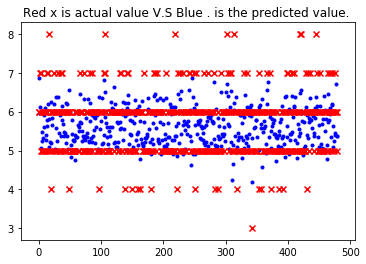

```python
xs = range(len(y_pred))
ys = y_pred
plt.title("Red x is actual value V.S Blue . is the predicted value. ")
plt.scatter(xs, ys, marker='.', color='b', label='predicted value')
ys = y_test
plt.scatter(xs, ys, marker='x', color='r', label='actual value')
plt.show()
```

# 2. Explain some of the assumptions followed in the parametric methods and non-parametric

methods? Please explain explain which method to use in which cases of the dataset. [10 Pts]

Assumption of parametric methods is parametric methods have fixed number of parameters and the dataset is normal distribution. For non-parametric methods, their parameter numbers depend on dataset size and the dataset is not normal distrubution.

https://www.statisticshowto.datasciencecentral.com/parametric-and-non-parametric-data/

# 3. Explain in detail about how logistic regression has been derived from Bernoulli distribution and when to apply logistic regression instead of linear regression ? [10 Pts]

The odds ratio: p/(1-p). (p means the positive event.) Then, define the logit: log(p/(1-p)). Finally, reverse the logit to get logistic or sigmoid.

When the result of the data is not linear, we use logistic regression.

# 4. Do the required exploratory data analysis and appply Logistic regression on the given

dataset ? The output should have your code, plots and below following values at the end (15 Pts for Exploratory data analysis and plots ,15 points for the rest of the algorithm )[30 Pts]

```python
df4=pd.read_csv('problem4.csv')
df4.head()
```

|  | male | age | education | currentSmoker | cigsPerDay | BPMeds | prevalentStroke | prevalentHyp | diabetes | totChol | sysBP | diaBP | BMI | heartRate | glucose | TenYearCHD |
| --- | --- | --- | --- | --- | --- | --- | --- | --- | --- | --- | --- | --- | --- | --- | --- | --- |
| 0 | 1 | 39 | 4.0 | 0 | 0.0 | 0.0 | 0 | 0 | 0 | 195.0 | 106.0 | 70.0 | 26.97 | 80.0 | 77.0 | 0 |
| 1 | 0 | 46 | 2.0 | 0 | 0.0 | 0.0 | 0 | 0 | 0 | 250.0 | 121.0 | 81.0 | 28.73 | 95.0 | 76.0 | 0 |
| 2 | 1 | 48 | 1.0 | 1 | 20.0 | 0.0 | 0 | 0 | 0 | 245.0 | 127.5 | 80.0 | 25.34 | 75.0 | 70.0 | 0 |
| 3 | 0 | 61 | 3.0 | 1 | 30.0 | 0.0 | 0 | 1 | 0 | 225.0 | 150.0 | 95.0 | 28.58 | 65.0 | 103.0 | 1 |
| 4 | 0 | 46 | 3.0 | 1 | 23.0 | 0.0 | 0 | 0 | 0 | 285.0 | 130.0 | 84.0 | 23.10 | 85.0 | 85.0 | 0 |

```python
df4.isnull().sum()
```

```
male                 0
age                  0
education          105
currentSmoker        0
cigsPerDay          29
BPMeds              53
prevalentStroke      0
prevalentHyp         0
diabetes             0
totChol             50
sysBP                0
diaBP                0
BMI                 19
heartRate            1
glucose            388
TenYearCHD           0
dtype: int64
```

```python
df4 = df4.dropna(axis = 0, how ='any')
```

```python
df4.isnull().sum()
```

```
male               0
age                0
education          0
currentSmoker      0
cigsPerDay         0
BPMeds             0
prevalentStroke    0
prevalentHyp       0
diabetes           0
totChol            0
sysBP              0
diaBP              0
BMI                0
heartRate          0
glucose            0
TenYearCHD         0
dtype: int64
```

```python
train4, test4 = train_test_split(df4, test_size = 0.30)

features = ["male", "age", "education", "currentSmoker", "cigsPerDay", "BPMeds", "prevalentStroke", "diabetes", "totChol", "sysBP", "diaBP", "BMI", "heartRate", "glucose"]

X_train4 = train4[features]
y_train4 = train4["TenYearCHD"]

X_test4 = test4[features]
y_test4 = test4["TenYearCHD"]
```

```python
X_train4_std = sc.fit_transform(X_train4)
X_test4_std = sc.fit_transform(X_test4)
```

```python
from sklearn.linear_model import LogisticRegression

logistic_model = LogisticRegression()
logistic_model.fit(X_train4_std, y_train4)
predictions = logistic_model.predict(X_test4_std)

print("Accuracy:", accuracy_score(y_test4.values, predictions))
# https://towardsdatascience.com/logistic-regression-a-simplified-approach-using-python-c4bc81a87c31
```

```
Accuracy: 0.8479052823315119
```

```python
from sklearn.metrics import confusion_matrix
confmat = confusion_matrix(y_true=y_test4, y_pred=predictions)

TP = confmat[0][0]
FN = confmat[0][1]
FP = confmat[1][0]
TN = confmat[1][1]
```

```python
Accuracy=TP+TN/(TP+TN+FP+FN)
Missclassifcation = 1-Accuracy
Sensitivity= TP/(TP+FN)
Specifcity= TN/(TN+FP)
Positive_Predictive= TP/(TP+FP)
Negative_predictive= TN/(TN+FN)
Positive_Likelihood_Ratio = Sensitivity/(1-Specifcity)
Negative_likelihood_Ratio = (1-Sensitivity)/Specifcity
```

```python
print("\n Accuracy=", Accuracy, "\n Missclassifcation=", Missclassifcation, "\n Sensitivity=", Sensitivity, "\n Specifcity=", Specifcity, "\n Positive_Predictive=", Positive_Predictive, "\n Negative_predictive=", Negative_predictive, "\n Positive_Likelihood_Ratio=", Positive_Likelihood_Ratio, "\n Negative_likelihood_Ratio=", Negative_likelihood_Ratio)
```

[output not shown]

```python
from sklearn.metrics import classification_report
print(classification_report(y_test4, predictions))
```

```
              precision    recall  f1-score   support

           0       0.85      0.99      0.92       920
           1       0.71      0.10      0.17       178

   micro avg       0.85      0.85      0.85      1098
   macro avg       0.78      0.54      0.54      1098
weighted avg       0.83      0.85      0.79      1098
```